# Distance Error Models

Garrett Frady and Tim Moore

2023-03-01

```r
# need to change the file name to match your path destination or change working directory
# setwd(dir = "Andys_Project_Info/")
dat <- read.csv("Master FPL Summary Data.csv")

# transform percents to proportions so values are between 0 and 1
dat$dist_err_propoff <- dat$dist_err_percentoff/100
```

# Experiment 1

```r
# EXPERIMENT 1
# same predictors as logistic regression models for success, with sequence included
mod.bayesian1 <- ordbetareg(dist_err_propoff ~ trial_type*path + trial_across_both_experiments +
                             (1|participant_number),
                           chains = 1,
                           data = dat %>% dplyr::filter(experiment == 1))

################### Model Summary ###################
# smmary of the model fit above
modsum1 <- modelsummary(mod.bayesian1, statistic = "conf.int", metrics = "RMSE")

# additional summary table of the model fit above
sumtab1 <- sjPlot::tab_model(mod.bayesian1)

################# Marginal Effects ##################
marg_effs1 <- marginaleffects(mod.bayesian1)

################ Posterior Estimation ################
all_draws1 <- prepare_predictions(mod.bayesian1)

# extract the model cutpoints and overlay them on the empirical distribution to ...
# ... see how the model is dividing the outcome into discrete-ish categories
# need totransform cutpoints using inverse logit function
cutzero1 <- plogis(all_draws1$dpars$cutzero)
cutone1 <- plogis(all_draws1$dpars$cutzero + exp(all_draws1$dpars$cutone))

# histograms of the cutpoints above; commented out as they are not necessary ...
# ... but I left them in case we were eventually interested
# hist(cutzero1)
# hist(cutone1)

# distribution of distance error proportion off including mean cutpoints as dotted lines
dist_err1_plot <- dat %>%
  ggplot(aes(x=dist_err_propoff)) +
  geom_histogram(bins=20) +
  theme_minimal() +
  theme(panel.grid=element_blank()) +
  scale_x_continuous(breaks=c(0, 0.25, 0.5, 0.75, 1)) +
  geom_vline(xintercept = mean(cutzero1),linetype=2) +
  geom_vline(xintercept = mean(cutone1),linetype=2) +
  xlim(c(0, 1)) +
  ylim(c(0, 20)) +
  ylab("") +
  xlab("") +
  labs(caption=paste0("Figure shows the distribution of  distance error proportion off."))

# posterior predictions
pred_post1 <- posterior_predict(mod.bayesian1, mod.bayesian1$dist_err_propoff)

# The discrete plot, which is a bar graph, shows that the posterior distributional...
# ... accurately captures the number of discrete responses in the data. For the ...
# continuous plot, shown as a density plot with one line per posterior draw, the ...
# model canbt capture all of the modality in the distribution b there are ...
# effectively four separate modes b but it is reasonably accurate over the middle ...
# responses and the responses near the bounds.
plots1 <- pp_check_ordbeta(mod.bayesian1, ndraws = 100)
```

## Model Fit

A summary of the model fit is given in the table below, along with an additional summary table. They contain similar information, so we can remove one eventually.

```r
modsum1
```

|  | B (1) |
| --- | --- |
| b_Intercept | b0.719 |
|  | [b1.860, 0.128] |
| b_trial_typeyes_belt | b1.297 |
|  | [b2.209, b0.431] |
| b_pathE1P2 | b0.007 |
|  | [b0.721, 0.777] |
| b_pathE1P3 | 0.122 |
|  | [b0.631, 0.884] |
| b_trial_across_both_experiments | 0.005 |
|  | [b0.104, 0.130] |
| b_trial_typeyes_belt C pathE1P2 | 0.647 |
|  | [b0.431, 1.706] |
| b_trial_typeyes_belt C pathE1P3 | b1.277 |
|  | [b2.898, 0.081] |
| sd_participant_number__Intercept | 0.784 |
|  | [0.387, 1.365] |
| phi | 3.587 |
|  | [2.450, 5.243] |
| Num.Obs. | 108 |
| RMSE | 0.18 |

```r
sumtab1
```

| B | dist err propoff |  |
| --- | --- | --- |
| Predictors | Estimates | CI (95%) |
| Intercept | -0.72 | -1.86B bB 0.13 |
| trial_typeyes_belt | -1.30 | -2.21B bB -0.43 |
| pathE1P2 | -0.01 | -0.72B bB 0.78 |
| pathE1P3 | 0.12 | -0.63B bB 0.88 |
| trial across both experiments | 0.00 | -0.10B bB 0.13 |
| trial_typeyes_belt:pathE1P2 | 0.65 | -0.43B bB 1.71 |
| trial_typeyes_belt:pathE1P3 | -1.28 | -2.90B bB 0.08 |
| phi | 3.59 | 2.45B bB 5.24 |
| Random Effects |  |  |
| O<sup>2</sup> | 0.01 |  |
| O<sub>00</sub> | 0.05 |  |
| ICC | 0.19 |  |
| N <sub>participant_number</sub> | 18 |  |
| Observations | 108 |  |
| Marginal R<sup>2</sup> / Conditional R<sup>2</sup> | 0.177 / 0.391 |  |

## Marginal Effects

```r
summary(marg_effs1) %>% knitr::kable()
```

| type | term | contrast | estimate | conf.low | conf.high |
| --- | --- | --- | --- | --- | --- |
| response | path | E1P2 - E1P1 | 0.0372302 | -0.0576469 | 0.1322971 |
| response | path | E1P3 - E1P1 | -0.0148425 | -0.1043307 | 0.0706634 |
| response | trial_across_both_experiments | dY/dX | 0.0007154 | -0.0154524 | 0.0180560 |
| response | trial_type | yes_belt - no_belt | -0.1890427 | -0.2616242 | -0.1226759 |

## Posterior Estimation

### Posterior Distribution

Below is a histogram representing the empirical distribution of distance error proportion off, including mean cutpoints as dotted lines, to see how the model divides the outcome into discrete-ish categories.

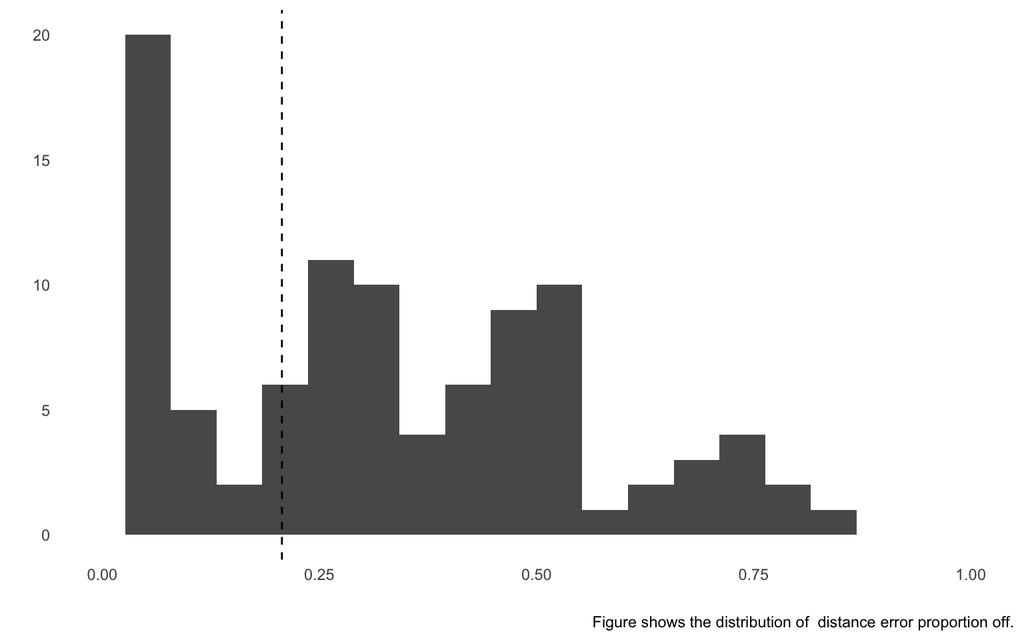

```r
dist_err1_plot
```

### Posterior Prediction

Below is a table representing the posterior estimates of dist_err_propoff for each observation in experiment 1. These are claculated from the posterior predictive distribution, and by averaging over all iterations (or draws).

```r
colMeans(pred_post1)
```

```
##   [1] 0.081021558 0.307277993 0.015644290 0.307659864 0.175652803 0.336119697
##   [7] 0.219855555 0.105260308 0.255537723 0.047818834 0.233904576 0.008732760
##  [13] 0.205708024 0.107051998 0.243412402 0.046788714 0.228085305 0.008001081
##  [19] 0.086470596 0.321544165 0.016798265 0.329011803 0.172766976 0.364694679
##  [25] 0.025351810 0.137524935 0.007238190 0.143811092 0.056653306 0.162556289
##  [31] 0.136696514 0.064484985 0.159679598 0.031572273 0.136072155 0.005936337
##  [37] 0.018219599 0.122408255 0.003570176 0.123905630 0.055165100 0.144129704
##  [43] 0.166114233 0.063909210 0.177536756 0.027207593 0.156923502 0.006288454
##  [49] 0.403260274 0.266169981 0.464964735 0.145888787 0.422102162 0.029513969
##  [55] 0.014490940 0.089326725 0.004035584 0.092015786 0.038853114 0.116450254
##  [61] 0.022091726 0.136582235 0.003470037 0.141432202 0.061108032 0.158862203
##  [67] 0.090887397 0.307434412 0.017153385 0.291933249 0.169203789 0.336971077
##  [73] 0.121155075 0.048863154 0.153963675 0.028202888 0.130390969 0.004768553
##  [79] 0.320386512 0.177777824 0.366774922 0.100553714 0.324775365 0.016960062
##  [85] 0.126410311 0.406993544 0.032314813 0.387451259 0.231345766 0.438168233
##  [91] 0.346784655 0.218989491 0.407848509 0.104299913 0.362767870 0.028588589
##  [97] 0.435742577 0.273217533 0.472779015 0.160443377 0.439879796 0.039768651
## [103] 0.104166116 0.362240475 0.024029650 0.330707915 0.201437394 0.391166150
```

The mean of all posterior estimates is shown below.

```r
mean(colMeans(pred_post1))
```

```
## [1] 0.1694823
```

## Posterior Checking

The discrete plot, which is a bar graph, shows that the posterior distributional accurately captures the number of discrete responses in the data. For the continuous plot, shown as a density plot with one line per posterior draw, the model canbt capture all of the modality in the distribution. The two plots are included below.

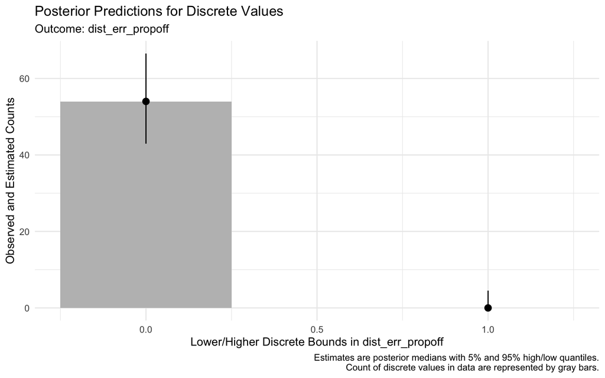

```r
plots1$discrete
```

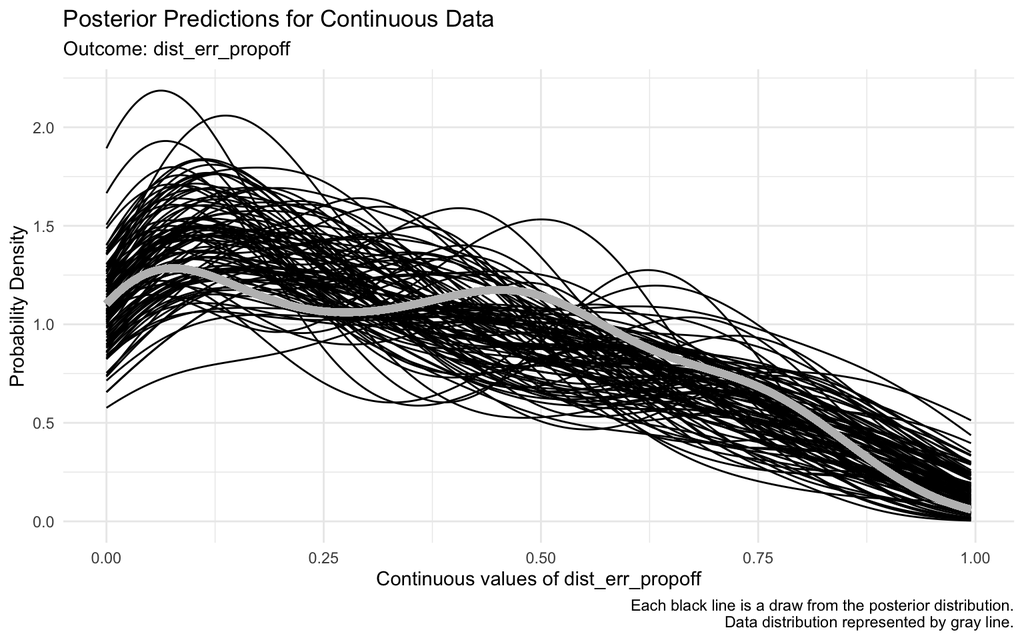

```r
plots1$continuous
```

# Experiment 2

```r
# EXPERIMENT 2
# same predictors as logistic regression models for success, with sequence included
mod.bayesian2 <- ordbetareg(dist_err_propoff ~ trial_type*path + trial_across_both_experiments +
                             (1|participant_number),
                           chains = 1,
                           data = dat %>% dplyr::filter(experiment == 2))

################### Model Summary ###################
# smmary of the model fit above
modsum2 <- modelsummary(mod.bayesian2, statistic = "conf.int", metrics = "RMSE")

# additional summary table of the model fit above
sumtab2 <- sjPlot::tab_model(mod.bayesian2)

################# Marginal Effects ##################
marg_effs2 <- marginaleffects(mod.bayesian2)

################ Posterior Estimation ################
all_draws2 <- prepare_predictions(mod.bayesian2)

# extract the model cutpoints and overlay them on the empirical distribution to ...
# ... see how the model is dividing the outcome into discrete-ish categories
# need totransform cutpoints using inverse logit function
cutzero2 <- plogis(all_draws2$dpars$cutzero)
cutone2 <- plogis(all_draws2$dpars$cutzero + exp(all_draws2$dpars$cutone))

# histograms of the cutpoints above; commented out as they are not necessary ...
# ... but I left them in case we were eventually interested
# hist(cutzero2)
# hist(cutone2)

# distribution of distance error proportion off including mean cutpoints as dotted lines
dist_err2_plot <- dat %>%
  ggplot(aes(x=dist_err_propoff)) +
  geom_histogram(bins=20) +
  theme_minimal() +
  theme(panel.grid=element_blank()) +
  scale_x_continuous(breaks=c(0, 0.25, 0.5, 0.75, 1)) +
  geom_vline(xintercept = mean(cutzero2),linetype=2) +
  geom_vline(xintercept = mean(cutone2),linetype=2) +
  xlim(c(0, 1)) +
  ylim(c(0, 20)) +
  ylab("") +
  xlab("") +
  labs(caption=paste0("Figure shows the distribution of  distance error proportion off."))

# posterior predictions
pred_post2 <- posterior_predict(mod.bayesian2, mod.bayesian2$dist_err_propoff)

# The discrete plot, which is a bar graph, shows that the posterior distributional...
# ... accurately captures the number of discrete responses in the data. For the ...
# continuous plot, shown as a density plot with one line per posterior draw, the ...
# model canbt capture all of the modality in the distribution b there are ...
# effectively four separate modes b but it is reasonably accurate over the middle ...
# responses and the responses near the bounds.
plots2 <- pp_check_ordbeta(mod.bayesian2, ndraws = 100)
```

## Model Fit

A summary of the model fit is given in the table below, along with an additional summary table. They contain similar information, so we can choose one eventually.

```r
modsum2
```

|  | B (1) |
| --- | --- |
| b_Intercept | b0.419 |
|  | [b1.090, 0.278] |
| b_trial_typeyes_belt | b1.123 |
|  | [b1.739, b0.491] |
| b_pathE2P2 | b1.655 |
|  | [b2.799, b0.428] |
| b_pathE2P3 | b0.248 |
|  | [b0.851, 0.376] |
| b_trial_across_both_experiments | b0.032 |
|  | [b0.105, 0.039] |
| b_trial_typeyes_belt C pathE2P2 | 1.183 |
|  | [b0.456, 2.660] |
| b_trial_typeyes_belt C pathE2P3 | b0.158 |
|  | [b1.183, 0.910] |
| sd_participant_number__Intercept | 0.144 |
|  | [0.008, 0.515] |
| phi | 4.307 |
|  | [2.912, 6.246] |
| Num.Obs. | 108 |
| RMSE | 0.16 |

```r
sumtab2
```

[output not shown]

## Marginal Effects

```r
summary(marg_effs2) %>% knitr::kable()
```

| type | term | contrast | estimate | conf.low | conf.high |
| --- | --- | --- | --- | --- | --- |
| response | path | E2P2 - E2P1 | -0.1311227 | -0.2145235 | -0.0305619 |
| response | path | E2P3 - E2P1 | -0.0453522 | -0.1236734 | 0.0307392 |
| response | trial_across_both_experiments | dY/dX | -0.0038906 | -0.0134718 | 0.0051391 |
| response | trial_type | yes_belt - no_belt | -0.1169382 | -0.1782400 | -0.0540559 |

## Posterior Estimation

### Posterior Distribution

Below is a histogram representing the empirical distribution of distance error proportion off, including mean cutpoints as dotted lines, to see how the model divides the outcome into discrete-ish categories.

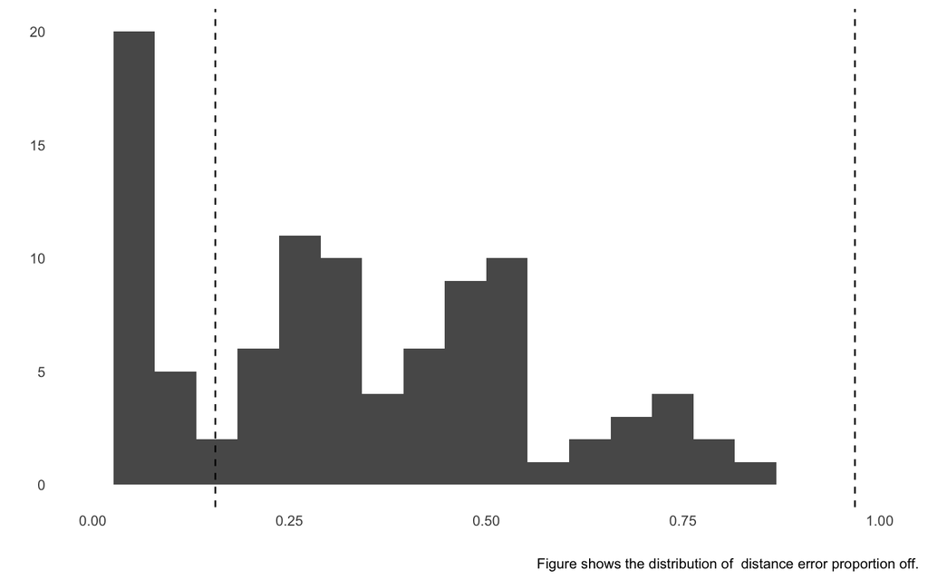

```r
dist_err2_plot
```

### Posterior Prediction

Below is a table representing the posterior estimates of dist_err_propoff for each observation in experiment 2. These are claculated from the posterior predictive distribution, and by averaging over all iterations (or draws).

```r
colMeans(pred_post2)
```

```
##   [1] 0.07720587 0.06575804 0.33932185 0.06650850 0.24479535 0.09723095
##   [7] 0.05115426 0.19268967 0.07127240 0.04500201 0.04197276 0.23211877
##  [13] 0.05632499 0.06421890 0.29130182 0.04830545 0.21859431 0.08423415
##  [19] 0.05705957 0.21669262 0.07546783 0.04019992 0.04152976 0.23462655
##  [25] 0.04816091 0.05826479 0.27405144 0.05310475 0.19643518 0.07261278
##  [31] 0.04623936 0.19129605 0.06029244 0.04007985 0.04185962 0.22220754
##  [37] 0.06123463 0.05881730 0.29448319 0.05713753 0.22024218 0.08099188
##  [43] 0.04907188 0.20074766 0.07245982 0.03804130 0.03642754 0.22167872
##  [49] 0.06644306 0.23884461 0.09272337 0.05359786 0.06022865 0.27750143
##  [55] 0.05374214 0.05017798 0.25840693 0.19830988 0.07442861 0.04825864
##  [61] 0.05688088 0.05681643 0.30478051 0.05325458 0.23275392 0.08798130
##  [67] 0.05072061 0.04122892 0.25941415 0.05146192 0.20273563 0.06783594
##  [73] 0.05452344 0.23906400 0.09111756 0.05105621 0.25466471 0.04581221
##  [79] 0.05216784 0.21361311 0.07208904 0.04405275 0.03954703 0.23334722
##  [85] 0.05065862 0.05733818 0.30024584 0.05133641 0.21270646 0.07362344
##  [91] 0.07746848 0.26941505 0.10332900 0.06364213 0.06288362 0.30434053
##  [97] 0.07424814 0.25658344 0.10178705 0.05225120 0.05536089 0.27859517
## [103] 0.04541102 0.05159019 0.26890635 0.04693325 0.19524947 0.06685487
```

```r
mean(colMeans(pred_post1))
```

```
## [1] 0.1694823
```

## Posterior Checking

The discrete plot, which is a bar graph, shows that the posterior distributional accurately captures the number of discrete responses in the data. For the continuous plot, shown as a density plot with one line per posterior draw, the model canbt capture all of the modality in the distribution. The two plots are included below.

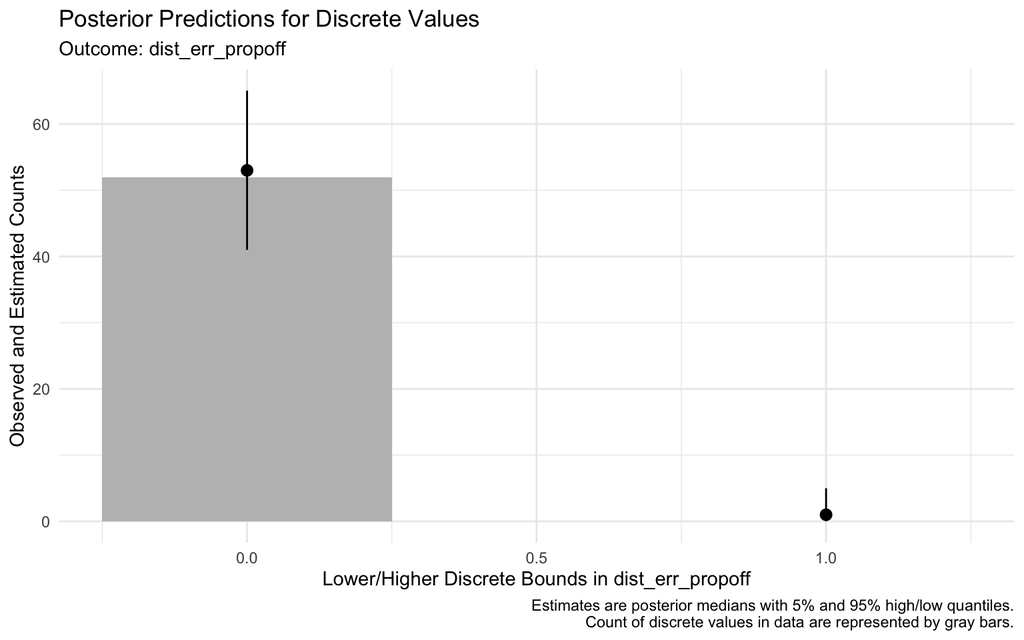

```r
plots2$discrete
```

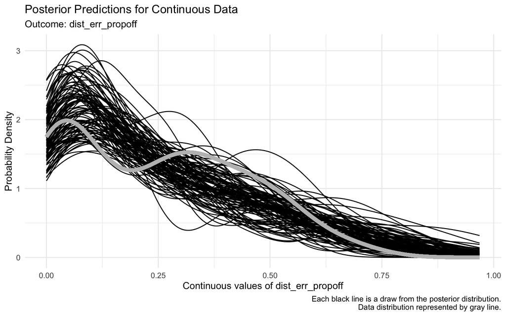

```r
plots2$continuous
```

# New Boxplots using Posterior Predictions for each individual

```r
# adding columns representing the posterior predictions of dist_err_propoff ...
# ... for each subject; one for experiment 1 and one for experiment 2
dat$posterior_predictions1 <- colMeans(pred_post1)
dat$posterior_predictions2 <- colMeans(pred_post2)
```

## Experiment 1

```r
dist_err_propoff_boxplot1 <- dat %>% filter(experiment == 1) %>%
  ggplot(aes(x = path, y = posterior_predictions1)) +
  geom_boxplot() +
  geom_point(aes(color = trial_type, shape = success), size = 3)

dist_err_propoff_boxplot1a <- dat %>% filter(experiment == 1) %>%
  ggplot(aes(x = path, y = posterior_predictions1, fill = trial_type)) +
  geom_boxplot() +
  facet_wrap(~trial_type) +
  geom_point(aes(shape = success), size = 3)

dist_err_propoff_boxplot1b <- dat %>% filter(experiment == 1) %>%
  ggplot(aes(x = path, y = posterior_predictions1, fill = trial_type)) +
  geom_boxplot()

dist_err_propoff_boxplot1c <- dat %>% filter(experiment == 1, success == "yes") %>%
  ggplot(aes(x = path, y = posterior_predictions1, fill = trial_type)) +
  geom_boxplot()

dist_err_propoff_boxplot1d <- dat %>% filter(experiment == 1, success == "no") %>%
  ggplot(aes(x = path, y = posterior_predictions1, fill = trial_type)) +
  geom_boxplot()
```

Boxplots of posterior predictions of dist_err_propoff for each subject, separated by path. The color of the points represent the trial_type (belt vs.B no belt) and the shapes represent the outcome of the trial (success = yes/no).

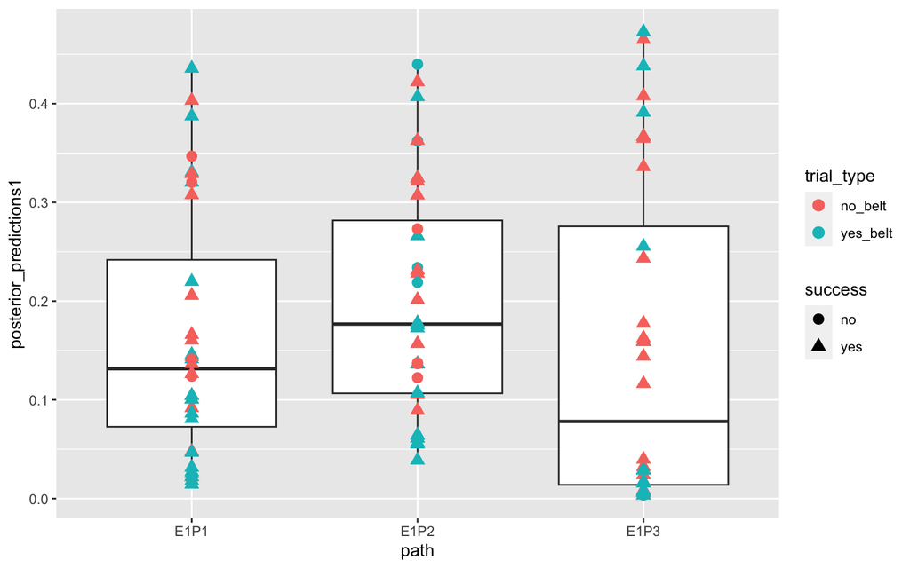

```r
dist_err_propoff_boxplot1
```

Now the boxplots are also separated by trial_type (belt vs no belt).

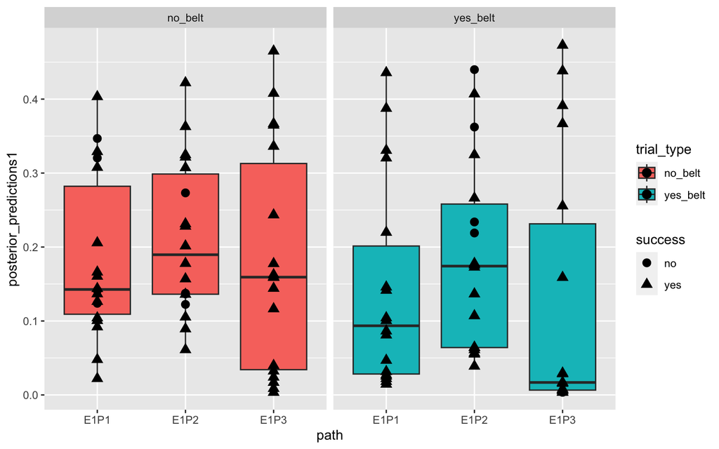

```r
dist_err_propoff_boxplot1a
```

LIKELY THE MAIN PLOT OF INTEREST

This plot is similar to the plot above, but we have further grouped the boxplots by trial_type for easier comparisons at each path. We also do not include the points regarding success (yes/no).

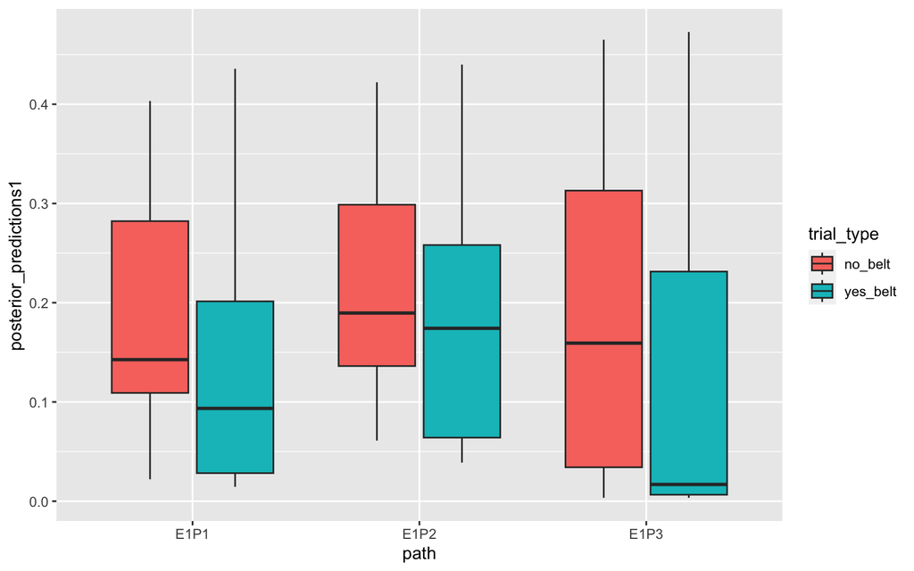

```r
dist_err_propoff_boxplot1b
```

The grid below contains two plots similar to the one above, however, they are separated based on success (yes/no). The plot on the left is for successful trials and the plot on the right is for failed trials.

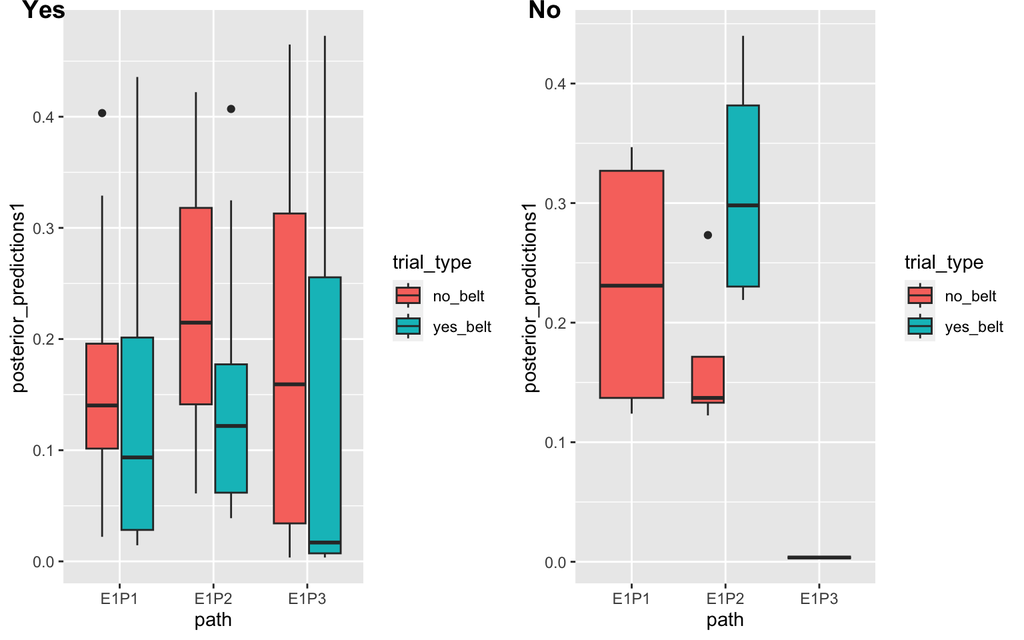

```r
cowplot::plot_grid(dist_err_propoff_boxplot1c, dist_err_propoff_boxplot1d, labels = c("Yes", "No"), vjust = 1)
```

## Experiment 2

```r
dist_err_propoff_boxplot2 <- dat %>% filter(experiment == 2) %>%
  ggplot(aes(x = path, y = posterior_predictions2)) +
  geom_boxplot() +
  geom_point(aes(color = trial_type, shape = success), size = 3)

dist_err_propoff_boxplot2a <- dat %>% filter(experiment == 2) %>%
  ggplot(aes(x = path, y = posterior_predictions2, fill = trial_type)) +
  geom_boxplot() +
  facet_wrap(~trial_type)

dist_err_propoff_boxplot2b <- dat %>% filter(experiment == 2) %>%
  ggplot(aes(x = path, y = posterior_predictions2, fill = trial_type)) +
  geom_boxplot()

dist_err_propoff_boxplot2c <- dat %>% filter(experiment == 2, success == "yes") %>%
  ggplot(aes(x = path, y = posterior_predictions2, fill = trial_type)) +
  geom_boxplot()

dist_err_propoff_boxplot2d <- dat %>% filter(experiment == 2, success == "no") %>%
  ggplot(aes(x = path, y = posterior_predictions2, fill = trial_type)) +
  geom_boxplot()
```

Boxplots of posterior predictions of dist_err_propoff for each subject, separated by path. The color of the points represent the trial_type (belt vs.B no belt) and the shapes represent the outcome of the trial (success = yes/no).

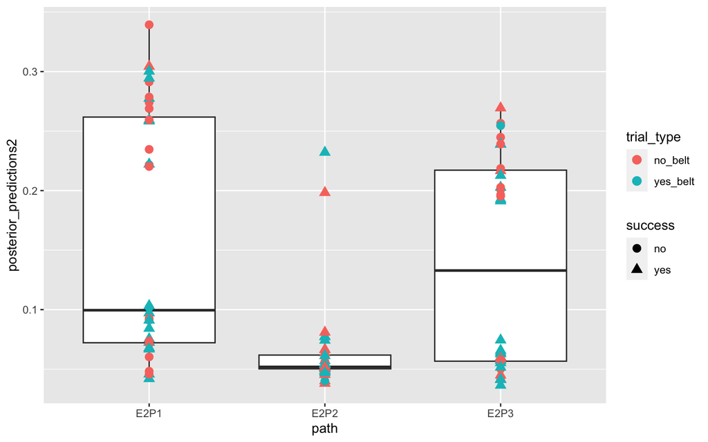

```r
dist_err_propoff_boxplot2
```

Now the boxplots are also separated by trial_type (belt vs no belt).

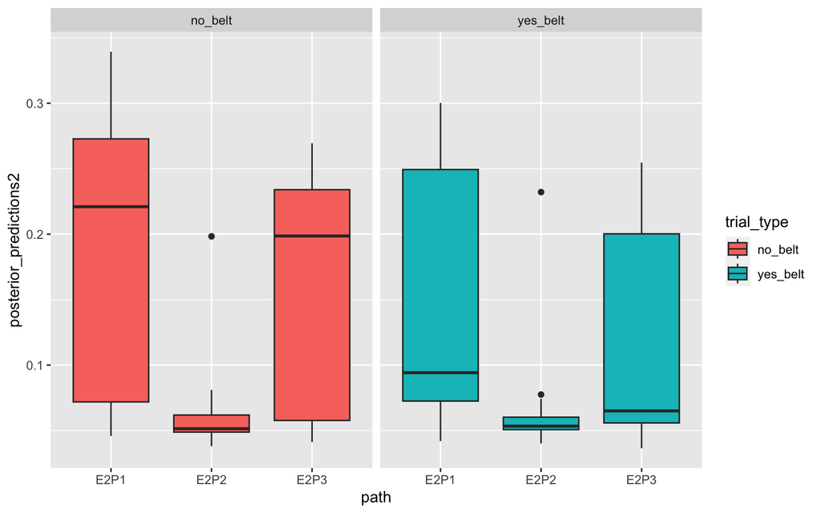

```r
dist_err_propoff_boxplot2a
```

LIKELY THE MAIN PLOT OF INTEREST

This plot is similar to the plot above, but we have further grouped the boxplots by trial_type for easier comparisons at each path. We also do not include the points regarding success (yes/no).

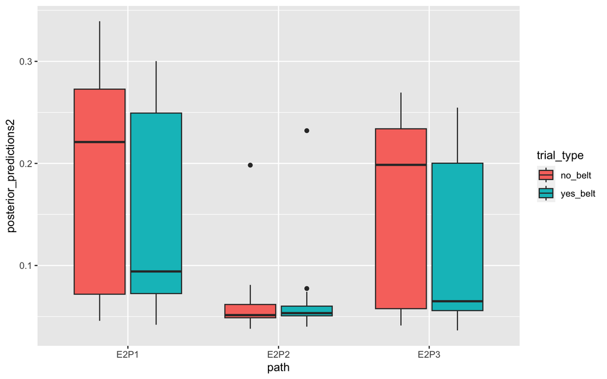

```r
dist_err_propoff_boxplot2b
```

The grid below contains two plots similar to the one above, however, they are separated based on success (yes/no). The plot on the left is for successful trials and the plot on the right is for failed trials.

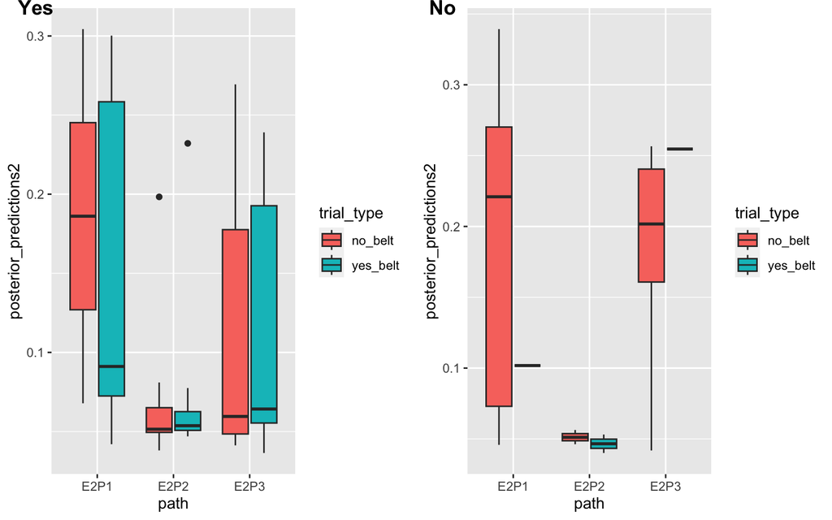

```r
cowplot::plot_grid(dist_err_propoff_boxplot2c, dist_err_propoff_boxplot2d, labels = c("Yes", "No"), vjust = 1)
```